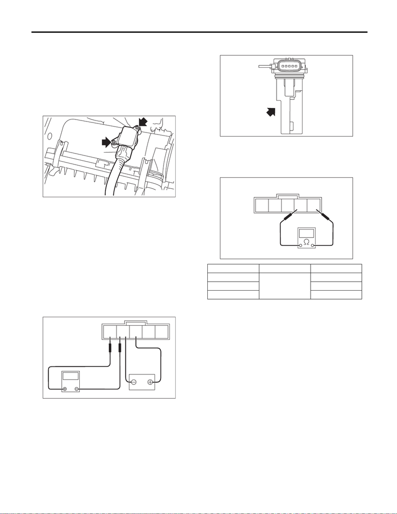

FU(STI)-40

Mass Air Flow and Intake Air Temperature Sensor

FUEL INJECTION (FUEL SYSTEMS)

9. Mass Air Flow and Intake Air

Temperature Sensor

A: REMOVAL

1) Disconnect the ground cable from battery.

2) Disconnect the connector (A) from the mass air

flow and intake air temperature sensor, and re-

move the mass air flow and intake air temperature

sensor.

B: INSTALLATION

Install in the reverse order of removal.

Tightening torque:

1 N·m (0.1 kgf-m, 0.7 ft-lb)

C: INSPECTION

1. CHECK THE MASS AIR FLOW SENSOR

UNIT

1) Connect the battery positive terminal to terminal

No. 3 and the battery ground terminal to terminal

No. 4, the circuit tester positive terminal to terminal

No. 5 and the circuit tester ground terminal to termi-

nal No. 4.

2) Check the voltage changes when air is blown to

the mass air flow sensor unit in arrow direction.

2. CHECK THE INTAKE AIR TEMPERA-

TURE SENSOR UNIT

Measure the resistance between intake air temper-

ature sensor terminals.

3. OTHER INSPECTIONS

1) Check that the mass air flow and intake air tem-

perature sensor has no deformation, cracks or oth-

er damages.

2) Check that the mass air flow and intake air tem-

perature sensor has no dirt.

FU-08438

(A)

5 4 3 2 1

FU-04062

V

Temperature Terminal No. Standard

–20°C (–4°F)

1 and 2

16.0±2.4 kΩ

20°C (68°F) 2.45±0.24 kΩ

60°C (140°F) 0.580±0.087 kΩ

FU-04063

FU-04064

5 4 3 2 1